# Kuis_DS_D

Ahmad Abdullah Azzam_123190013

10/29/2021

##Intro ##Baca Petunjuk Terlebih Dahulu!

1. Kerjakan soal-soal yang ada! Jangan lupa tulis NAMA dan NIM pada author!
2. Kuis terdiri dari 2 bagian yaitu bagian pertama dan bagian kedua
3. Jawablah dengan mengisi chunk dibawah soal!
4. Durasi pengerjaan sesuai selama 12 jam, dikumpulkan maksimal Jum’at, 29 Oktober 2021 pukul 21.00 WIB
5. No toleransi pengumpulan telat. Ingat, telat kemungkinan terburuk ga ada nilai kuis!
6. Misal soal rancu bisa menghubungi asisten terkait
7. Export hasil pekerjaan dalam format PDF/Word & sesuaikan nama file sesuai NIM masing-masing.

##BAGIAN PERTAMA

1. Load library apa saja yang kira-kira digunakan! Lalu gunakan data ‘us_contagious_diseases’! **point 1**

```r
library(dslabs)
library(dplyr)
data(us_contagious_diseases)
```

2. Tampilkan semua nama kolom pada data frame yang ada! **point 5**

```r
names(us_contagious_diseases)
```

```
## [1] "disease"         "state"           "year"            "weeks_reporting"
## [5] "count"           "population"
```

3. Tampilkan tipe data pada kolom penyakit! **point 5**

```r
class(us_contagious_diseases$disease)
```

```
## [1] "factor"
```

4. Tampilkan 10 data penyakit rubella teratas diurutkan berdasarkan jumlah kasusnya dan terjadi pada antara tahun 2000 dan 2005! **point 11**

```r
rubella=us_contagious_diseases[which(us_contagious_diseases$disease == "Rubella"),]
datax=rubella[which(rubella$year>=2000&rubella$year<=2005),]
x<-arrange(.data=datax, -count)
head(x,10)
```

```
##    disease          state year weeks_reporting count population
## 1  Rubella North Carolina 2000              36    82    8049313
## 2  Rubella South Carolina 2000              40    14    4012012
## 3  Rubella     California 2000              32    11   33871648
## 4  Rubella  Massachusetts 2000              39     6    6349097
## 5  Rubella          Texas 2000              34     5   20851820
## 6  Rubella        Florida 2001              32     4   16272186
## 7  Rubella        Alabama 2000              37     3    4447100
## 8  Rubella       Illinois 2001              46     3   12501805
## 9  Rubella     California 2002              29     2   34529758
## 10 Rubella        Florida 2000              33     2   15982378
```

5. Klasifikasikan data tersebut berdasarkan jumlah kasusnya dengan kondisi : -jumlah kasus kurang dari 500 dikategorikan sebagai “Biasa” -jumlah kasus lebih dari 2000 dikategorikan sebagai “Azab -jumlah kasus antara kedua kondisi diatas dikategorikan sebagai”Cobaan"

NB : jika dirasa jumlah data hasilnya terlalu banyak boleh menggunakan fungsi top_n() atau head()**point 10**

```r
df1<-mutate(us_contagious_diseases, category=case_when(count<500~"Biasa",count>2000~"Azab",TRUE~"Cobaan"))
head(df1,10)
```

```
##        disease   state year weeks_reporting count population category
## 1  Hepatitis A Alabama 1966              50   321    3345787    Biasa
## 2  Hepatitis A Alabama 1967              49   291    3364130    Biasa
## 3  Hepatitis A Alabama 1968              52   314    3386068    Biasa
## 4  Hepatitis A Alabama 1969              49   380    3412450    Biasa
## 5  Hepatitis A Alabama 1970              51   413    3444165    Biasa
## 6  Hepatitis A Alabama 1971              51   378    3481798    Biasa
## 7  Hepatitis A Alabama 1972              45   342    3524543    Biasa
## 8  Hepatitis A Alabama 1973              45   467    3571209    Biasa
## 9  Hepatitis A Alabama 1974              45   244    3620548    Biasa
## 10 Hepatitis A Alabama 1975              46   286    3671246    Biasa
```

6. Tambahkan variabel baru berisi data ‘us_contagious_diseases’ dengan tambahan kolom baru dengan nama “category” yang isinya merupakan implementasi nomor 5 dan kolom “rate” yang isinya merupakan hasil bagi jumlah kasus dengan populasi dikalikan 100000! **point 10**

```r
df2<-mutate(df1, rate=count/population*100000)
head(df2,10)
```

```
##        disease   state year weeks_reporting count population category      rate
## 1  Hepatitis A Alabama 1966              50   321    3345787    Biasa  9.594155
## 2  Hepatitis A Alabama 1967              49   291    3364130    Biasa  8.650082
## 3  Hepatitis A Alabama 1968              52   314    3386068    Biasa  9.273293
## 4  Hepatitis A Alabama 1969              49   380    3412450    Biasa 11.135694
## 5  Hepatitis A Alabama 1970              51   413    3444165    Biasa 11.991295
## 6  Hepatitis A Alabama 1971              51   378    3481798    Biasa 10.856460
## 7  Hepatitis A Alabama 1972              45   342    3524543    Biasa  9.703386
## 8  Hepatitis A Alabama 1973              45   467    3571209    Biasa 13.076804
## 9  Hepatitis A Alabama 1974              45   244    3620548    Biasa  6.739311
## 10 Hepatitis A Alabama 1975              46   286    3671246    Biasa  7.790271
```

7. Tampilkan kesimpulan pada data nomor 6 dikelompokkan berdasarkan negara bagian yang isinya nama negara bagian dan rata-rata rate per negara bagian! **point 8**

```r
dataa <- select(df2, state, rate)
dataa1<-distinct(dataa, state, .keep_all = TRUE)
summary(dataa1)
```

```
##         state         rate
##  Alabama   : 1   Min.   : 2.089
##  Alaska    : 1   1st Qu.: 8.816
##  Arizona   : 1   Median :13.670
##  Arkansas  : 1   Mean   :15.946
##  California: 1   3rd Qu.:18.578
##  Colorado  : 1   Max.   :55.077
##  (Other)   :45
```

8. Lakukan visualisasi pada hasil nomor 7!(Bebas menggunakan plot, boxplot, hist, ggplot2 dsb) **point 5**

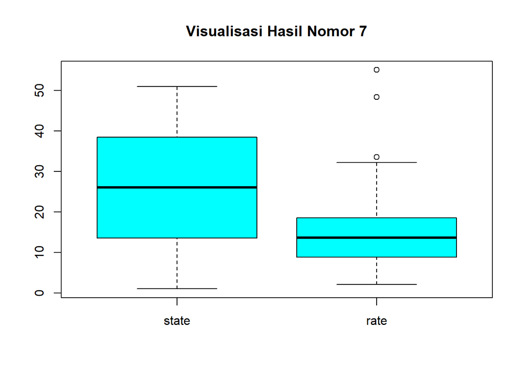

```r
boxplot(dataa1, col=c("cyan"), cex.main=1.2, main="Visualisasi Hasil Nomor 7")
```

##BAGIAN KEDUA

1. Load library tambahan untuk import file! **point 2**

```r
library(dplyr)
fdata=read.csv("worldwide_covid_data.csv")
```

2. Tampilkan informasi rinci tentang struktur dataset yang digunakan! **point 5**

```r
str(fdata)
```

```
## 'data.frame':    196 obs. of  10 variables:
##  $ Country                     : chr  "Afghanistan" "Albania" "Algeria" "Andorra" ...
##  $ Total_Cases                 : int  156071 182610 205990 15425 64033 4031 5283000 298069 15848 163866 ...
##  $ Total_Deaths                : int  7262 2888 5899 130 1702 99 115866 6112 171 1669 ...
##  $ Total_Recovered             : num  128000 172464 141335 15205 52833 ...
##  $ Active_Cases                : num  20809 7258 58756 90 9498 ...
##  $ Total_Cases_per1M_population: int  3894 63546 4589 199217 1872 40718 115496 100342 147611 6329 ...
##  $ Deaths_per1M_population     : int  181 1005 131 1679 50 1000 2533 2058 1593 64 ...
##  $ Total_Tests                 : num  771431 1289520 230861 193595 1092363 ...
##  $ Tests_per1M_population      : num  19247 448738 5143 2500323 31933 ...
##  $ Population                  : int  40080392 2873656 44892255 77428 34207984 98997 45741769 2970540 107363 25889279 ...
```

3. Tampilkan 10 nama Negara dengan jumlah kasus Covid-19 yang terkonfirmasi dari paling banyak ke paling sedikit! **point 8**

```r
df<-data.frame(fdata)
x<-arrange(.data=df, desc(Total_Cases))
head(x[1:2],10)
```

```
##      Country Total_Cases
## 1        USA    46497719
## 2      India    34215653
## 3     Brazil    21748984
## 4         UK     8853227
## 5     Russia     8316019
## 6     Turkey     7909111
## 7     France     7133766
## 8       Iran     5877456
## 9  Argentina     5283000
## 10     Spain     5004143
```

4. Buat kolom baru bernama Rate_Deaths yang berisi rasio korban Covid-19 yang meninggal dengan yang terkonfirmasi! **point 11**

```r
new_df1<-mutate(fdata, Rate_Deaths=Total_Deaths/Total_Cases)
new_df1
```

```
##                    Country Total_Cases Total_Deaths Total_Recovered
## 1              Afghanistan      156071         7262          128000
## 2                  Albania      182610         2888          172464
## 3                  Algeria      205990         5899          141335
## 4                  Andorra       15425          130           15205
## 5                   Angola       64033         1702           52833
## 6      Antigua and Barbuda        4031           99            3541
## 7                Argentina     5283000       115866         5149181
## 8                  Armenia      298069         6112          263002
## 9                    Aruba       15848          171           15513
## 10               Australia      163866         1669          130922
## 11                 Austria      804825        11279          760336
## 12              Azerbaijan      520068         6939          486426
## 13                 Bahamas       22259          642           20261
## 14                 Bahrain      276635         1393          274640
```

[output cut: 576 more lines]

5. Negara mana yang memiliki rasio kematian Covid-19 tertinggi dan terendah? Tampilkan nama negaranya. **point 11**

```r
i_max<-which.max(new_df1$Rate_Deaths)
i_min<-which.min(new_df1$Rate_Deaths)
##TERTINGGI
new_df1$Country[i_max]
```

```
## [1] "Yemen"
```

```r
##TERENDAH
new_df1$Country[i_min]
```

```
## [1] "Bhutan"
```

6. Tampilkan grafik plot antara penderita yang sembuh dengan penderita yang terkonfirmasi Covid-19! **point 8**

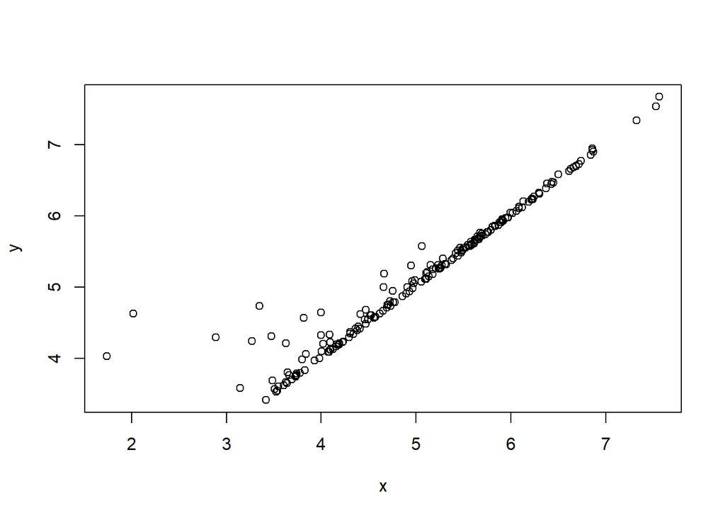

```r
x<-log10(new_df1$Total_Recovered)
y<-log10(new_df1$Total_Cases)
plot(x,y)
```